# ATELIER 7 : TRANSPORT

Auteur·rice

AFFELI N’Dri Marius Arthur, AKE Brice Patrick, NGUESSAN Kouakou Firmain

Date de publication

2025-05-27

> Exemple de traitement réalisé par les groupes d’auditeur à partir de l’enquête AfroMapR.

# 1. Préparation des données

## Choix des variables à analyser

On sélectionne dans le tableau une variable Y que l’on veut expliquer et une variables X qui peut servir à expliquer Y. On décide par exemple d’examiner les variables suivantes :

- **Y : transport** : Mode de transport pour venir au marché de Bouaké
- **X : raison** : motif de la présence au marché de Bouaké

## Recodage éventuel des étiquettes

On peut raccourcir ou modifier les étiquettes pour faciliter leur affichage ou fusionner des modalités trop peu nombreuses. Ici on a décidé de regrouper les modes de transport en 5 catégories afin d’avoir des effectifs suffisant dans chaque classe. Pour la même raison, on a regroupé les motifs de présence au marché en trois catégories seulement.

# 2. Analyse de la variable à expliquer Y

## Fréquence simple

| Modalité | Fréquence |
| --- | --- |
| Auto | 29 |
| Autre | 12 |
| Moto | 22 |
| Taxi | 17 |
| Taxi-moto | 34 |
| Sum | 114 |

## Pourcentage

| Modalité | % |
| --- | --- |
| Auto | 25.4 |
| Autre | 10.5 |
| Moto | 19.3 |
| Taxi | 14.9 |
| Taxi-moto | 29.8 |
| Sum | 100.0 |

## Diagramme en bâtons

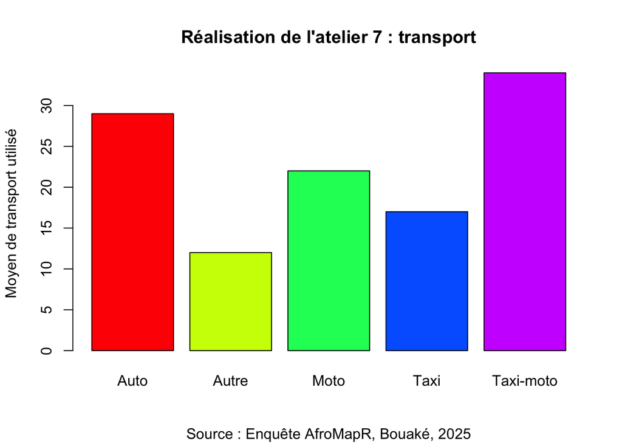

# 3. Analyse de la variable explicative X

## Fréquence simple

| Modalité | Fréquence |
| --- | --- |
| Autre | 36 |
| Commerçant | 44 |
| Grossiste | 34 |
| Sum | 114 |

## Pourcentage

| Modalité | % |
| --- | --- |
| Autre | 31.6 |
| Commerçant | 38.6 |
| Grossiste | 29.8 |
| Sum | 100.0 |

## Diagramme en bâtons

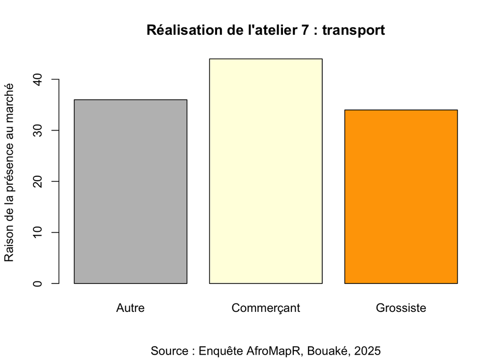

# 4. Relation entre X et Y

## Hypothèses

On veut tester l’existence d’une relation entre les deux variables précédentes.

- **H0** : Il n’y a pas de relation entre X et Y
- **H1** : Il y a une relation entre X et Y
- **Justification de l’hypothèse H1** : On suppose que les acteurs du marché disposent de ressources économiques différentes qui les conduisent à utiliser des modes de transport plus oumoins coûteux et rapides.

## Tableau de contingence

|  | Auto | Autre | Moto | Taxi | Taxi-moto | Sum |
| --- | --- | --- | --- | --- | --- | --- |
| Autre | 3 | 8 | 5 | 11 | 9 | 36 |
| Commerçant | 14 | 2 | 7 | 4 | 17 | 44 |
| Grossiste | 12 | 2 | 10 | 2 | 8 | 34 |
| Sum | 29 | 12 | 22 | 17 | 34 | 114 |

## Pourcentage en ligne

|  | Auto | Autre | Moto | Taxi | Taxi-moto | Sum |
| --- | --- | --- | --- | --- | --- | --- |
| Autre | 8.3 | 22.2 | 13.9 | 30.6 | 25.0 | 100 |
| Commerçant | 31.8 | 4.5 | 15.9 | 9.1 | 38.6 | 100 |
| Grossiste | 35.3 | 5.9 | 29.4 | 5.9 | 23.5 | 100 |
| Sum | 25.4 | 10.5 | 19.3 | 14.9 | 29.8 | 100 |

On constate de très fortes différences de mode de transport selon les acteurs du marché. Par exemple, la moto et l’automobile individuelle est plus pratiquée par les grossistes. Les commerçants utilisent beaucoup le taxi-modo et l’automodible. Les autres personnes présentes sur le marchévont plus utiliser le taxi et les modes de transports divers tels que la marche.

## Graphique en mosaïque

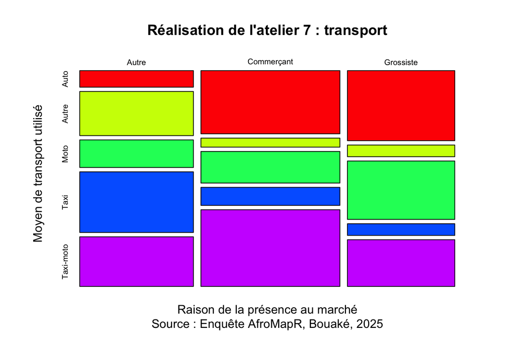

## Test du chi-2

On part de l’hypothèse nulle H0 : il n’y a pas de relation entre X et Y. Les variations en Y en fonction de X sont l’effet du hasard.

On effectue un test du chi-2 qui donne les résultats suivants :

```
    Pearson's Chi-squared test

data:  tabcont
X-squared = 26.268, df = 8, p-value = 0.000945
```

## Conclusion

Pour que le test du chi-2 soit pleinement valable, il faudrait soit accroître la taille de l’échantillon, soit procéder à des regroupements des variables en catégories moins nombreuses.